# Geographic Variarion of Iridescence

Coley Tosto

2023-03-05

```r
library(car)
library(knitr)
library(kableExtra)
library(tidyverse)
library(multcompView)
library(MASS)
library(ggplot2)
library(cowplot)
```

```r
##Function used to add Tukey Letters to Boxplot Figures
generate_label_df <- function(TUKEY, variable){

  #Extract labels and factor levels from Tukey post-hoc test
  Tukey.levels <- TUKEY[[variable]][, 4]
  Tukey.labels <- data.frame(multcompLetters(Tukey.levels)['Letters'])

  #Putting the labels in the same order as in the boxplot :
  Tukey.labels$treatment=rownames(Tukey.labels)
  Tukey.labels=Tukey.labels[order(Tukey.labels$treatment) , ]
  return(Tukey.labels)
}
```

```r
geo_data <- read.csv("processed_data/geo.csv")
geo_data$Location <- as.factor(geo_data$Location)

##The subsetted data created as per the next section
geo_subset <- read.csv("processed_data/geovar.csv")
geo_subset$Location <- as.factor(geo_subset$Location)

##This dataset is used for the band area vs iridescence analysis
area_iri <- read.csv("processed_data/ehs-LOCATION.csv")
```

## Subsetting the dataset

In order to run a one-way ANOVA to see if iridescence is different across the different geographic populations, we needed an equal sample size for each pop. The original dataset contained 18, 18, 17, and 19 female pipefish from the Florida Anne’s Beach, Florida Fort De Soto, Texas South Padre, and Texas Port Aransas population respectively. The smallest sample size (TX South Padre), was then chosen as the number randomly sampled from the other populations.

```r
##Subsetting the individual populations
FLAB<-subset(geo_data,Location=="FLAB")
FLFD<-subset(geo_data,Location=="FLFD")
TXSP<-subset(geo_data,Location=="TXSP")
TXPA<-subset(geo_data,Location=="TXPA")

##Randomly selecting 17 from each population
flabw<-FLAB[sample(1:nrow(FLAB),17,replace=FALSE),]
flfdw<-FLFD[sample(1:nrow(FLFD),17,replace=FALSE),]
txspw<-TXSP[sample(1:nrow(TXSP),17,replace=FALSE),]
txpaw<-TXPA[sample(1:nrow(TXPA),17,replace=FALSE),]
set.seed(123) ##Allows for reproducability if re-run in the same session

##Combining the new subsets in a new dataset
geovar<-rbind(flabw,flfdw,txspw,txpaw)

##Writing out the dataset to ensure it is the same if further analysis is needed
write.csv(geovar,"geovar.csv")
```

## Analysis

Summarized Data

| Location | depth | band_num | mean_hard | total_easy |
| --- | --- | --- | --- | --- |
| FLAB | 7.131941 | 15.88235 | 0.2551946 | 12.177635 |
| FLFD | 7.141000 | 15.29412 | 0.2427085 | 6.636094 |
| TXPA | 5.686471 | 17.64706 | 0.1728293 | 7.765618 |
| TXSP | 3.993647 | 18.94118 | 0.1774011 | 6.760818 |

Note:  
Summarized here are the means across location for each of the variables

### Length across Location

#### Summary table

Summarized Data

| Location | length_mean | length_SD |
| --- | --- | --- |
| FLAB | 119.68006 | 12.294545 |
| FLFD | 123.96988 | 13.118810 |
| TXPA | 105.34053 | 9.071285 |
| TXSP | 93.53071 | 8.737943 |

#### Histogram

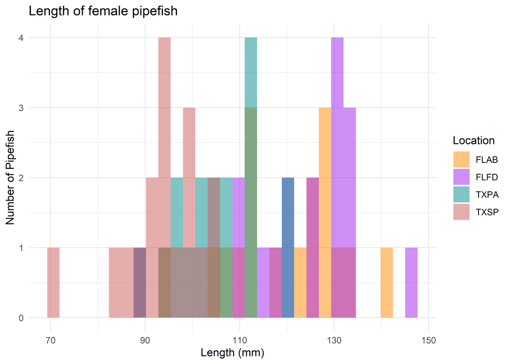

Histogram of female body length (mm) across the four locations

#### Testing assumptions

```r
leveneTest(length~Location, geo_subset)
```

```
## Levene's Test for Homogeneity of Variance (center = median)
##       Df F value Pr(>F)
## group  3  1.2105 0.3131
##       64
```

```r
lengthaov<-aov(geo_subset$length~geo_subset$Location)
lengthresid<-resid(lengthaov)
shapiro.test(lengthresid)
```

```
##
##  Shapiro-Wilk normality test
##
## data:  lengthresid
## W = 0.96973, p-value = 0.09677
```

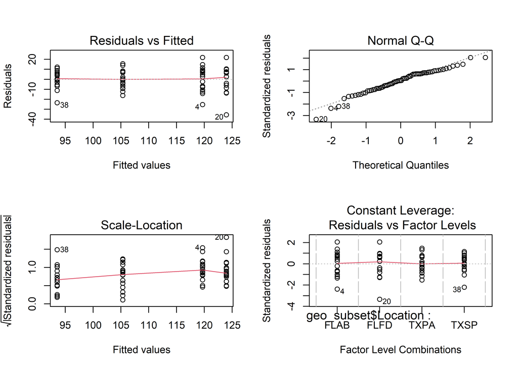

```r
par(mfrow=c(2,2))
plot(lengthaov)
```

All assumptions met, can proceed with one-way ANOVA.

#### Running one-way ANOVA between Length and Location

```r
summary(lengthaov)
```

```
##                     Df Sum Sq Mean Sq F value   Pr(>F)
## geo_subset$Location  3   9864    3288   27.29 1.74e-11 ***
## Residuals           64   7710     120
## ---
## Signif. codes:  0 '***' 0.001 '**' 0.01 '*' 0.05 '.' 0.1 ' ' 1
```

```r
#Post-hoc Analysis
tukey_length <- TukeyHSD(x=lengthaov, 'geo_subset$Location', conf.level = 0.95)
tukey_length
```

```
##   Tukey multiple comparisons of means
##     95% family-wise confidence level
##
## Fit: aov(formula = geo_subset$length ~ geo_subset$Location)
##
## $`geo_subset$Location`
##                 diff        lwr        upr     p adj
## FLFD-FLAB   4.289824  -5.641033  14.220681 0.6666855
## TXPA-FLAB -14.339529 -24.270386  -4.408672 0.0017542
## TXSP-FLAB -26.149353 -36.080210 -16.218496 0.0000000
## TXPA-FLFD -18.629353 -28.560210  -8.698496 0.0000335
## TXSP-FLFD -30.439176 -40.370033 -20.508319 0.0000000
## TXSP-TXPA -11.809824 -21.740681  -1.878967 0.0134179
```

Significant ANOVA results. From the post-hoc analysis we can see significant differences between the lengths of females from the Florida and Texas populations.

```
## $`geo_subset$Location`
## FLFD FLAB TXPA TXSP
##  "a"  "a"  "b"  "c"
```

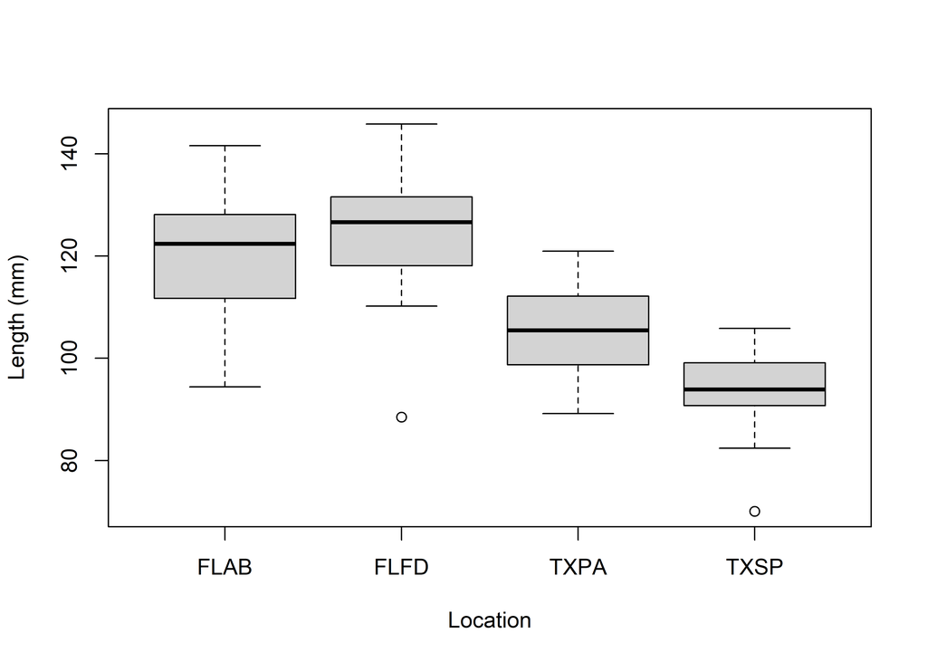

### Depth across Location

#### Summary table

Summarized Data

| Location | depth_mean | depth_SD |
| --- | --- | --- |
| FLAB | 7.131941 | 1.0159922 |
| FLFD | 7.141000 | 1.1368301 |
| TXPA | 5.686471 | 0.6121274 |
| TXSP | 3.993647 | 0.6627263 |

#### Histogram

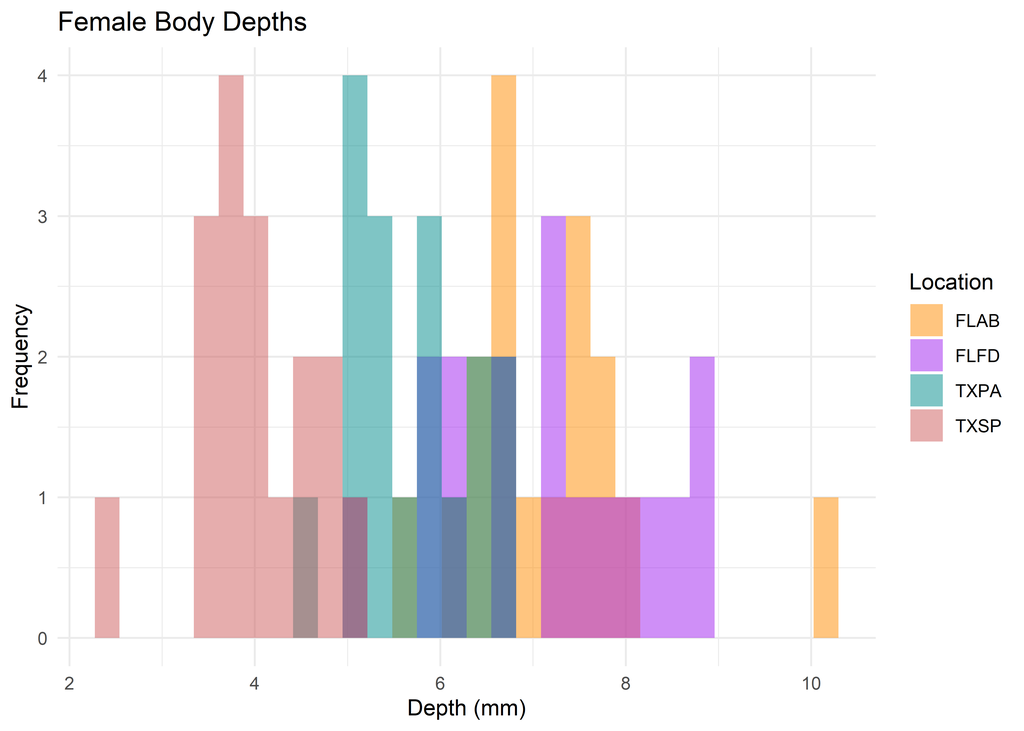

Histogram of female body depth(mm) across the four locations

#### Testing assumptions

```r
leveneTest(depth~Location, geo_subset)
```

```
## Levene's Test for Homogeneity of Variance (center = median)
##       Df F value Pr(>F)
## group  3  2.0593 0.1144
##       64
```

```r
depthaov<-aov(geo_subset$depth~geo_subset$Location)
depthresid<-resid(depthaov)
shapiro.test(depthresid)
```

```
##
##  Shapiro-Wilk normality test
##
## data:  depthresid
## W = 0.97809, p-value = 0.2749
```

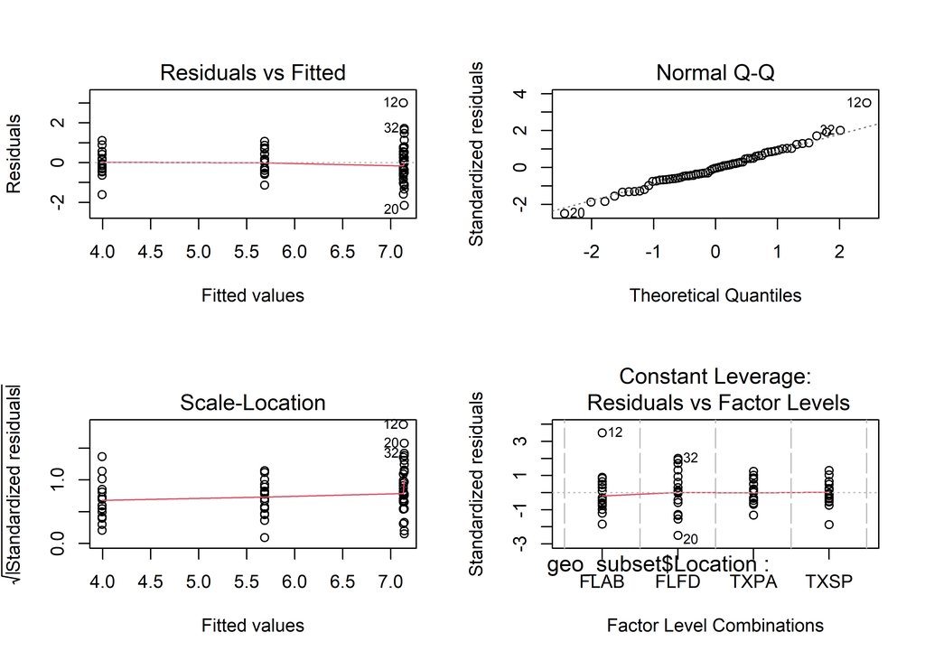

```r
par(mfrow=c(2,2))
plot(depthaov)
```

All assumptions met, can proceed with one-way ANOVA.

#### Running one-way ANOVA between Depth and Location

```r
summary(depthaov)
```

```
##                     Df Sum Sq Mean Sq F value Pr(>F)
## geo_subset$Location  3 114.01   38.00   48.43 <2e-16 ***
## Residuals           64  50.22    0.78
## ---
## Signif. codes:  0 '***' 0.001 '**' 0.01 '*' 0.05 '.' 0.1 ' ' 1
```

```r
#Post-hoc Analysis
tukey_depth <- TukeyHSD(x=depthaov, 'geo_subset$Location', conf.level = 0.95)
tukey_depth
```

```
##   Tukey multiple comparisons of means
##     95% family-wise confidence level
##
## Fit: aov(formula = geo_subset$depth ~ geo_subset$Location)
##
## $`geo_subset$Location`
##                   diff        lwr        upr     p adj
## FLFD-FLAB  0.009058824 -0.7923827  0.8105003 0.9999904
## TXPA-FLAB -1.445470588 -2.2469121 -0.6440291 0.0000672
## TXSP-FLAB -3.138294118 -3.9397356 -2.3368526 0.0000000
## TXPA-FLFD -1.454529412 -2.2559709 -0.6530879 0.0000603
## TXSP-FLFD -3.147352941 -3.9487945 -2.3459114 0.0000000
## TXSP-TXPA -1.692823529 -2.4942651 -0.8913820 0.0000032
```

Significant ANOVA results. From the post-hoc analysis we can see significant differences between the depths of females from the Florida and Texas populations and between the two Texas populations.

```
## $`geo_subset$Location`
## FLFD FLAB TXPA TXSP
##  "a"  "a"  "b"  "c"
```

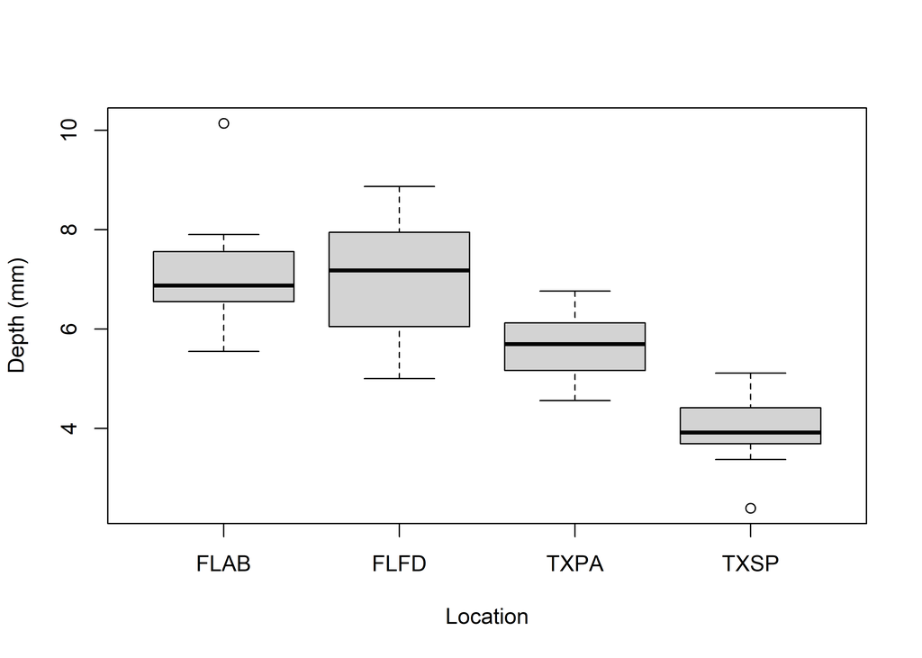

Because of the difference in depths across the locations for all of the subsequent analyses iridescent measurements will be adjusted for by depth (iridescence/depth) resulting in Depth-adjust iridescence measurements.

### Number of female bands across Location

#### Summary table

Summarized Data

| Location | band_num_mean | band_num_SD |
| --- | --- | --- |
| FLAB | 15.88235 | 1.833110 |
| FLFD | 15.29412 | 1.212678 |
| TXPA | 17.64706 | 2.370158 |
| TXSP | 18.94118 | 2.357715 |

#### Histogram

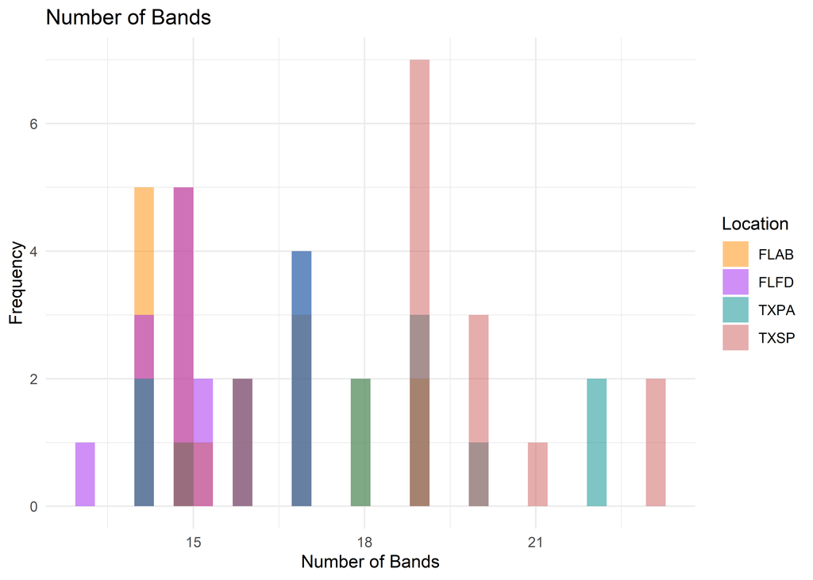

Histogram of number of iridescent female bands across the four locations

#### Testing assumptions

```r
leveneTest(band_num~Location, geo_subset)
```

```
## Levene's Test for Homogeneity of Variance (center = median)
##       Df F value Pr(>F)
## group  3  1.3565 0.2641
##       64
```

```r
band_num_aov<-aov(geo_subset$band_num~geo_subset$Location)
band_numresid<-resid(band_num_aov)
shapiro.test(band_numresid)
```

```
##
##  Shapiro-Wilk normality test
##
## data:  band_numresid
## W = 0.98035, p-value = 0.3589
```

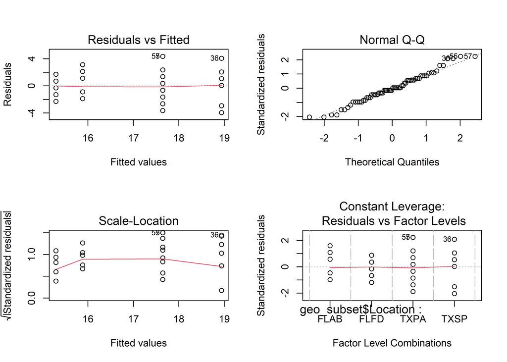

```r
par(mfrow=c(2,2))
plot(band_num_aov)
```

#### Running one-way ANOVA between Number of Bands and Location

```r
summary(band_num_aov)
```

```
##                     Df Sum Sq Mean Sq F value   Pr(>F)
## geo_subset$Location  3  141.7   47.22    11.8 3.02e-06 ***
## Residuals           64  256.1    4.00
## ---
## Signif. codes:  0 '***' 0.001 '**' 0.01 '*' 0.05 '.' 0.1 ' ' 1
```

```r
#Post-hoc Analysis
tukey_bandnum <- TukeyHSD(x=band_num_aov, 'geo_subset$Location', conf.level = 0.95)
tukey_bandnum
```

```
##   Tukey multiple comparisons of means
##     95% family-wise confidence level
##
## Fit: aov(formula = geo_subset$band_num ~ geo_subset$Location)
##
## $`geo_subset$Location`
##                 diff         lwr      upr     p adj
## FLFD-FLAB -0.5882339 -2.39819187 1.221724 0.8266614
## TXPA-FLAB  1.7647066 -0.04525135 3.574665 0.0586368
## TXSP-FLAB  3.0588240  1.24886609 4.868782 0.0001961
## TXPA-FLFD  2.3529405  0.54298258 4.162898 0.0057270
## TXSP-FLFD  3.6470580  1.83710002 5.457016 0.0000085
## TXSP-TXPA  1.2941174 -0.51584050 3.104075 0.2442289
```

```
## $`geo_subset$Location`
## TXSP TXPA FLAB FLFD
##  "a" "ab" "bc"  "c"
```

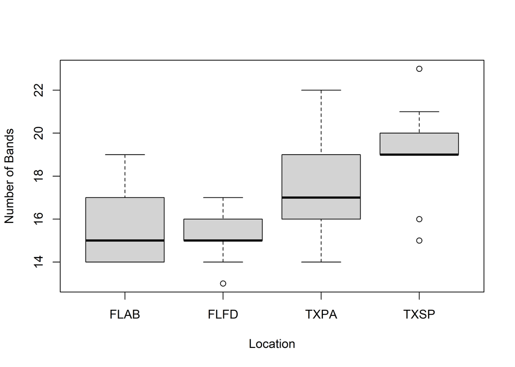

#### Creating Figure

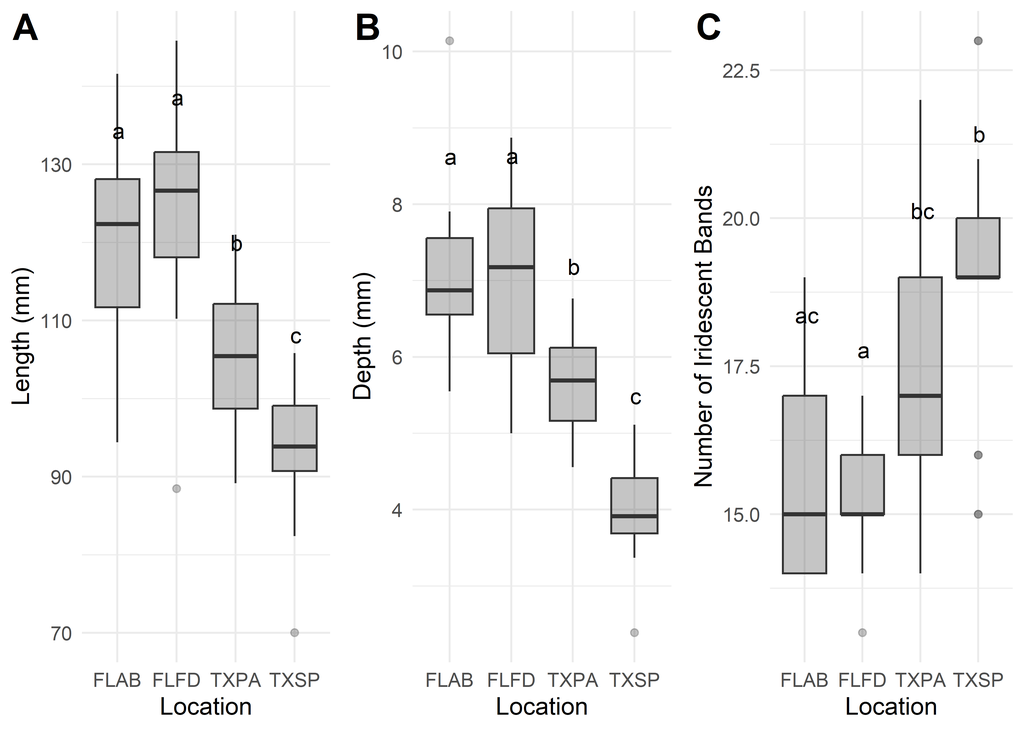

### Depth-adjusted Mean Band Iridescence across Location

#### Summary table

Summarized Data

| Location | DAI_hard_mean | DAI_hard_SD |
| --- | --- | --- |
| FLAB | 0.0350523 | 0.0217445 |
| FLFD | 0.0333968 | 0.0161817 |
| TXPA | 0.0301637 | 0.0116977 |
| TXSP | 0.0441479 | 0.0106199 |

#### Histogram

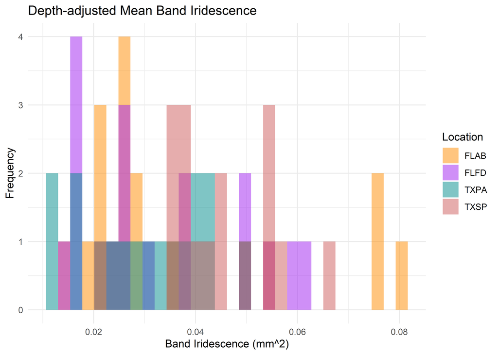

Histogram of Depth-adjusted mean band iridescence across the four locations

#### Testing assumptions

```r
leveneTest(DAI_hard~Location, geo_subset)
```

```
## Levene's Test for Homogeneity of Variance (center = median)
##       Df F value Pr(>F)
## group  3  0.8039 0.4963
##       64
```

```r
bandiri <- aov(DAI_hard~Location, geo_subset)
bandiriresid <- resid(bandiri)
shapiro.test(bandiriresid)
```

```
##
##  Shapiro-Wilk normality test
##
## data:  bandiriresid
## W = 0.9236, p-value = 0.0004666
```

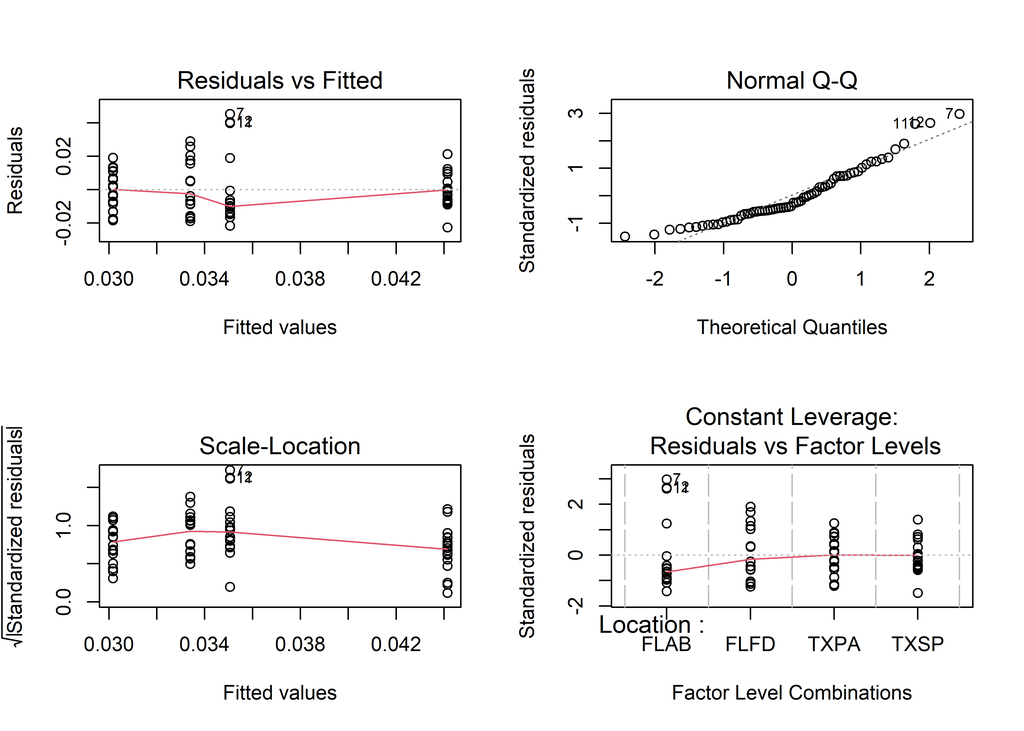

```r
par(mfrow=c(2,2))
plot(bandiri)
```

All assumptions are not met, data fails normality as tested with shapiro.test. Cannot run a simple one-way ANOVA. Instead will use a GLMM with an underlying quasi-poisson distribution.

#### Running the model between Depth-adjusted Mean Band Iridescence and Location

```r
bandiriPS <- glmmPQL(DAI_hard~Location,
                     random=~1|Location,
                     family=quasipoisson,
                     data=geo_subset)
```

```
## iteration 1
```

```r
Anova(bandiriPS, type="III")
```

```
## Analysis of Deviance Table (Type III tests)
##
## Response: zz
##                 Chisq Df Pr(>Chisq)
## (Intercept) 1000.5705  1    < 2e-16 ***
## Location       7.6117  3    0.05476 .
## ---
## Signif. codes:  0 '***' 0.001 '**' 0.01 '*' 0.05 '.' 0.1 ' ' 1
```

Non-significant results, mean band iridescence does not differ between populations.

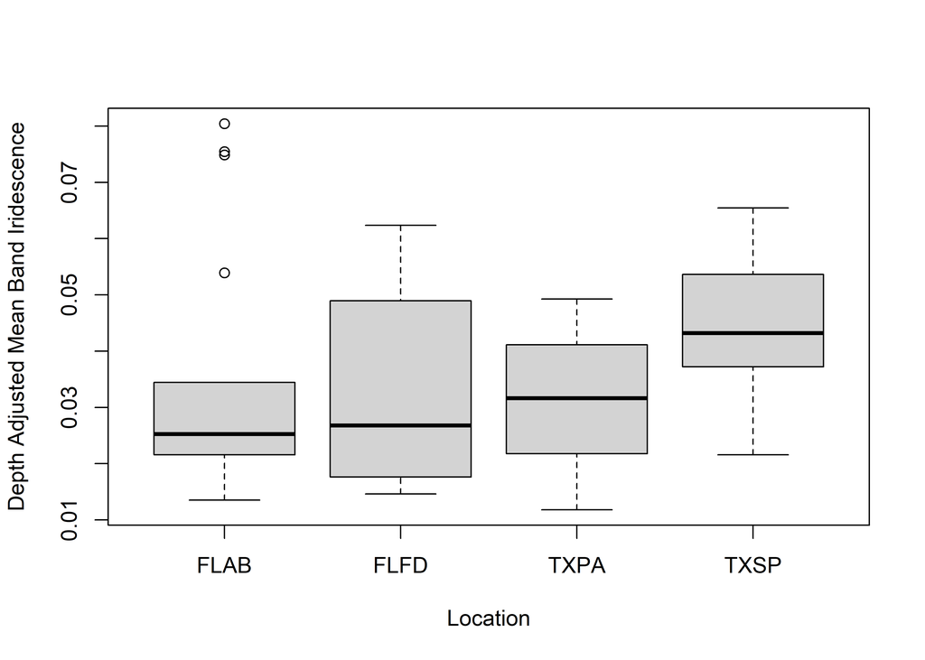

### Depth-adjusted Overall Iridescence across Location

#### Summary table

Summarized Data

| Location | DAIT_easy_mean | DAIT_easy_SD |
| --- | --- | --- |
| FLAB | 1.6669564 | 0.6231963 |
| FLFD | 0.8983221 | 0.3434524 |
| TXPA | 1.3484604 | 0.4134546 |
| TXSP | 1.6624073 | 0.4279989 |

#### Histogram

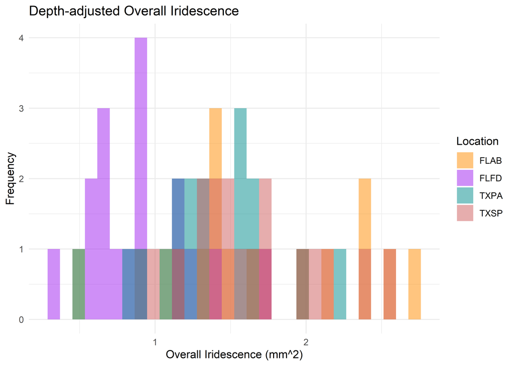

Histogram of Depth-adjusted overall iridescence across the four locations

#### Testing assumptions

```r
leveneTest(DAIT_easy~Location, geo_subset)
```

```
## Levene's Test for Homogeneity of Variance (center = median)
##       Df F value Pr(>F)
## group  3  2.0445 0.1165
##       64
```

```r
overalliri <- aov(geo_subset$DAIT_easy~geo_subset$Location)
overalliriresid <- resid(overalliri)
shapiro.test(overalliriresid)
```

```
##
##  Shapiro-Wilk normality test
##
## data:  overalliriresid
## W = 0.97826, p-value = 0.2806
```

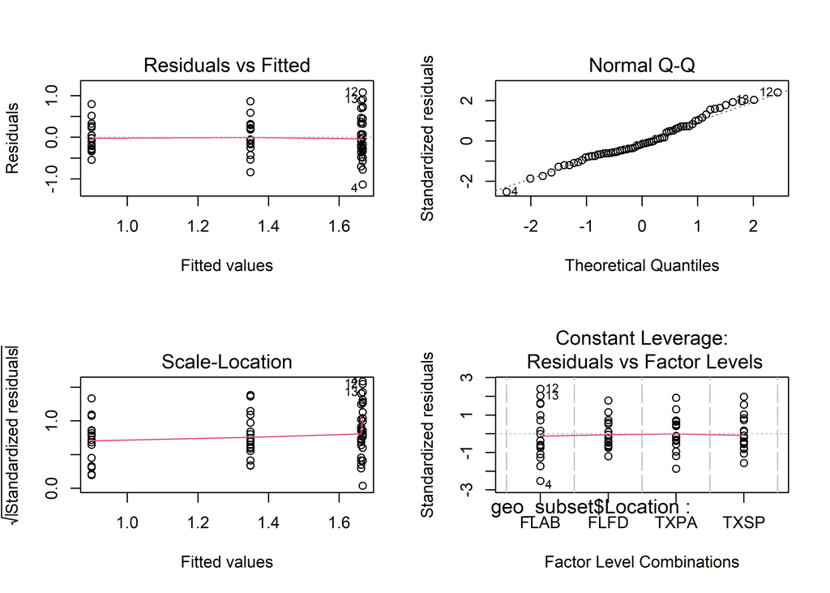

```r
par(mfrow=c(2,2))
plot(overalliri)
```

All assumptions are met, can proceed with a one-way ANOVA

#### Running the one-way ANOVA between Depth-adjusted Overall Iridescence and Location

```r
summary(overalliri)
```

```
##                     Df Sum Sq Mean Sq F value   Pr(>F)
## geo_subset$Location  3  6.703  2.2345   10.39 1.17e-05 ***
## Residuals           64 13.767  0.2151
## ---
## Signif. codes:  0 '***' 0.001 '**' 0.01 '*' 0.05 '.' 0.1 ' ' 1
```

```r
##Post-hoc analysis
tukey_overalliri <- TukeyHSD(x=overalliri, 'geo_subset$Location', conf.level = 0.95)
tukey_overalliri
```

```
##   Tukey multiple comparisons of means
##     95% family-wise confidence level
##
## Fit: aov(formula = geo_subset$DAIT_easy ~ geo_subset$Location)
##
## $`geo_subset$Location`
##                   diff         lwr        upr     p adj
## FLFD-FLAB -0.768634342 -1.18827189 -0.3489968 0.0000513
## TXPA-FLAB -0.318496071 -0.73813362  0.1011415 0.1980000
## TXSP-FLAB -0.004549171 -0.42418672  0.4150884 0.9999915
## TXPA-FLFD  0.450138271  0.03050073  0.8697758 0.0308429
## TXSP-FLFD  0.764085171  0.34444763  1.1837227 0.0000570
## TXSP-TXPA  0.313946900 -0.10569065  0.7335844 0.2087737
```

Significant results from ANOVA. From the post-hoc analysis we can see signifcant differences between FL fort de soto population and the other three.

```
## $`geo_subset$Location`
## FLAB TXSP TXPA FLFD
##  "a"  "a"  "a"  "b"
```

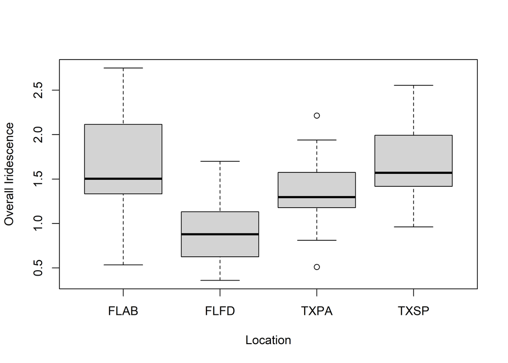

### Torso Iridescence across Location

#### Summary table

Summarized Data

| Location | body_iri_mean | body_iri_SD |
| --- | --- | --- |
| FLAB | 7.946929 | 3.821406 |
| FLFD | 2.955685 | 2.254426 |
| TXPA | 4.630618 | 1.795938 |
| TXSP | 3.330288 | 1.579604 |

#### Histogram

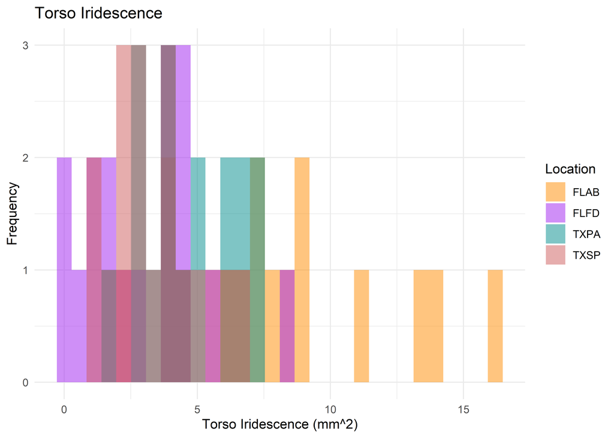

Histogram of Torso iridescence across the four locations

#### Testing assumptions

```r
leveneTest(body_iri~Location, geo_subset)
```

```
## Levene's Test for Homogeneity of Variance (center = median)
##       Df F value  Pr(>F)
## group  3  3.5081 0.02018 *
##       64
## ---
## Signif. codes:  0 '***' 0.001 '**' 0.01 '*' 0.05 '.' 0.1 ' ' 1
```

```r
torsoiri_aov <- aov(body_iri~Location, geo_subset)
torsoiriresid <- resid(torsoiri_aov)
shapiro.test(torsoiriresid)
```

```
##
##  Shapiro-Wilk normality test
##
## data:  torsoiriresid
## W = 0.96434, p-value = 0.04887
```

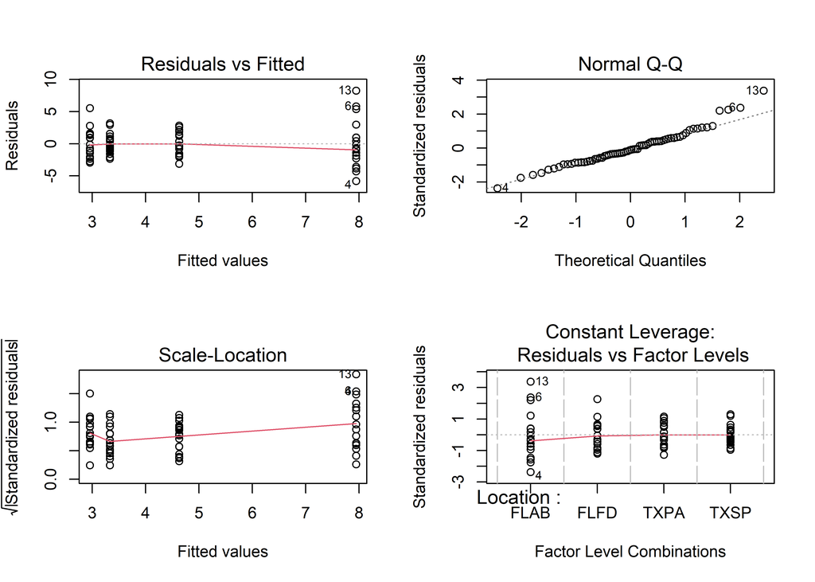

```r
par(mfrow=c(2,2))
plot(torsoiri_aov)
```

All assumptions are not met, data fails normality as tested with shapiro.test. Cannot run a simple one-way ANOVA. Instead will use a GLMM with an underlying quasi-poisson distribution.

#### Running the model between Torso Iridescence and Location

```r
torsoiriPS <- glmmPQL(body_iri~Location,
                    random=~1|Location,
                    family=quasipoisson,
                    data=geo_subset)
```

```
## iteration 1
```

```r
Anova(torsoiriPS, type="III")
```

```
## Analysis of Deviance Table (Type III tests)
##
## Response: zz
##               Chisq Df Pr(>Chisq)
## (Intercept) 493.088  1  < 2.2e-16 ***
## Location     44.638  3  1.105e-09 ***
## ---
## Signif. codes:  0 '***' 0.001 '**' 0.01 '*' 0.05 '.' 0.1 ' ' 1
```

Significant results, but no corresponding post-hoc test for this model so we can’t see which locations are sig.different from each other

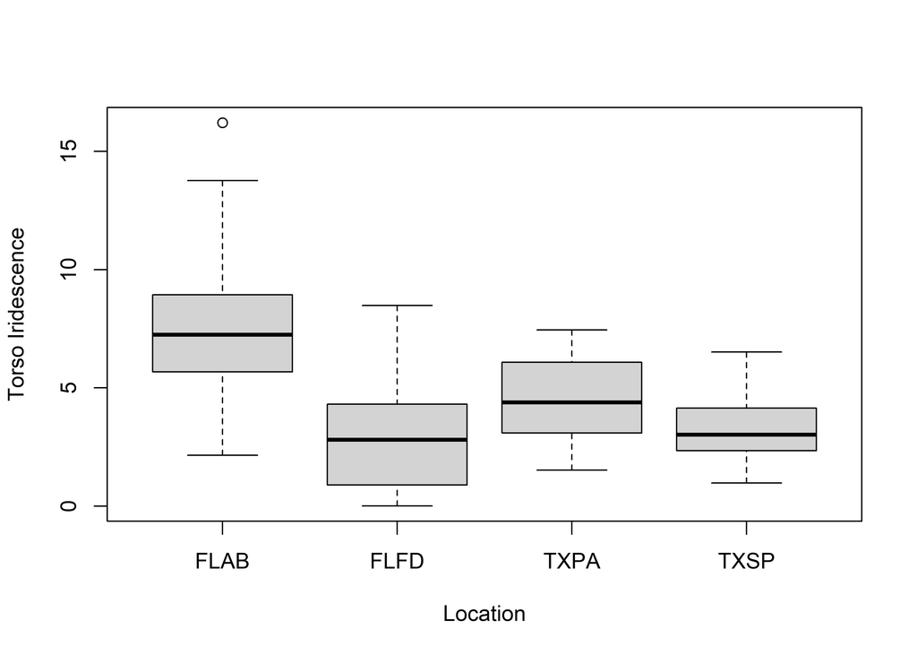

### Creating the Figure

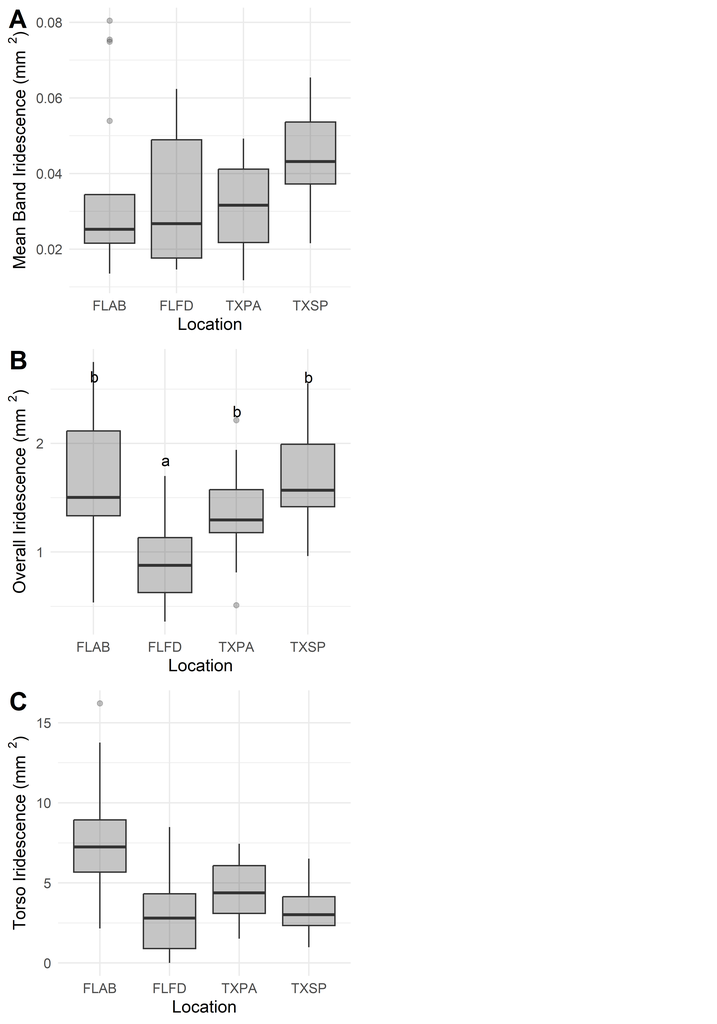

### Investigating the Relationship between Band Area and Band Iridescence

```r
FLABehs <- subset(area_iri, Location=="FLAB")
FLFDehs <- subset(area_iri, Location=="FLFD")
TXSPehs <- subset(area_iri, Location=="TXSP")
```

#### Investigating correlations between area and iridescence

```r
##Looking at the correlation in the whole dataset
cor.test(area_iri$mean_sarah, area_iri$mean_hard) ##0.3685
```

```
##
##  Pearson's product-moment correlation
##
## data:  area_iri$mean_sarah and area_iri$mean_hard
## t = 2.831, df = 51, p-value = 0.006624
## alternative hypothesis: true correlation is not equal to 0
## 95 percent confidence interval:
##  0.1090932 0.5809468
## sample estimates:
##       cor
## 0.3685204
```

```r
##Looking at correlations within each Location
cor.test(FLABehs$mean_sarah, FLABehs$mean_hard) ##0.2455675
```

```
##
##  Pearson's product-moment correlation
##
## data:  FLABehs$mean_sarah and FLABehs$mean_hard
## t = 1.0133, df = 16, p-value = 0.326
## alternative hypothesis: true correlation is not equal to 0
## 95 percent confidence interval:
##  -0.2499600  0.6391592
## sample estimates:
##       cor
## 0.2455675
```

```r
cor.test(FLFDehs$mean_sarah, FLFDehs$mean_hard) ##0.400215
```

```
##
##  Pearson's product-moment correlation
##
## data:  FLFDehs$mean_sarah and FLFDehs$mean_hard
## t = 1.7469, df = 16, p-value = 0.09983
## alternative hypothesis: true correlation is not equal to 0
## 95 percent confidence interval:
##  -0.08197123  0.73057780
## sample estimates:
##      cor
## 0.400215
```

```r
cor.test(TXSPehs$mean_sarah, TXSPehs$mean_hard) ##0.4177789
```

```
##
##  Pearson's product-moment correlation
##
## data:  TXSPehs$mean_sarah and TXSPehs$mean_hard
## t = 1.7809, df = 15, p-value = 0.09518
## alternative hypothesis: true correlation is not equal to 0
## 95 percent confidence interval:
##  -0.07866126  0.74818560
## sample estimates:
##       cor
## 0.4177789
```

Overall no strong correlations seen between band area and band iridescence, with the lowest correlation in the FL Anne’s Beach population. This would probably be expected as those females possessed the most iridescence on the torso but not specifically located to the bands.

#### Creating Figure

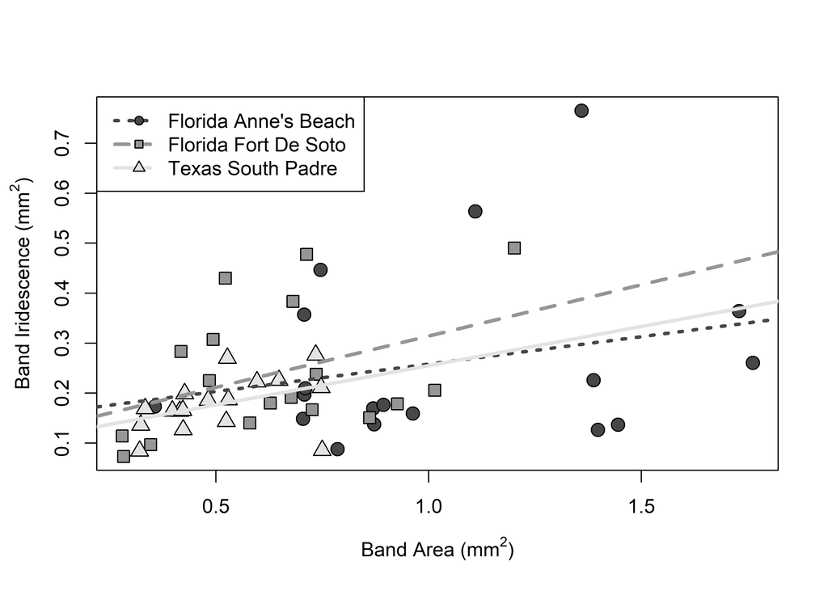